# Marketplace economics modeling

```python
import numpy as np
import pandas as pd
import seaborn as sns

from IPython.core.display import display, HTML
import ipywidgets as widgets

import matplotlib.pyplot as plt
import matplotlib.dates as mdates
import matplotlib.ticker as mtick

import math
import uuid

from calendar import monthrange
import easing
```

```python
from faker import Faker
import random

faker = Faker('pt_BR')
```

```python
mode_offline = False
```

```python
pd.set_option('display.float_format', lambda x: '%.3f' % x)
```

## Helpers

Specific helper functions for this notebook. For shared utilities, please consider to use `utils.py` or create a new library.

```python
def create_seller(seller_tier, period, seller_count, index):

    global faker
    global seller_tiers_df
    global seller_ls

    price = seller_tiers_df.loc[seller_tier]['price'][random.randint(0, len(seller_tiers_df.loc[seller_tier]['price']) - 1)]

    day = int(round((index / seller_count * 27)+1))

    created_at = '{}-{:02d}'.format(period, day)

    seller_dt = {
        '_id' : [
            uuid.uuid4()
        ],
        'createdAt' : [
            created_at
        ],
        'period' : [
            period
        ],
        'name' : [
            faker.name()
        ],
        'tier' : [
            seller_tier
        ],
        'price' : [
            price
        ],
        'profession' : [
            faker.job()
        ]
    }

    seller_df = pd.DataFrame(data=seller_dt)
    seller_ls.append(seller_df)
```

```python
def create_sellers(seller_count, seller_tier, period):
    i = 0
    while i < seller_count:
        create_seller(seller_tier, period, seller_count, i)
        i += 1
```

```python
def create_order(period, order_count, index, tier):

    global faker
    global order_ls

    seller = get_seller_by_period(period)
    day = int(round((index / order_count * 27)+1))
    created_at = '{}-{:02d}'.format(period, day)

    price = seller['price'].values[0]

    # gross_profit = price * split_df.loc['Marketplace']['rate']
    gross_profit = price * marketplace_rate
    # amount_for_psp = price * marketplace_split_df.loc['PSP']['rate']
    amount_for_psp = price * psp_rate
    # amount_for_taxes = gross_profit * taxes_df['rate'].sum()
    amount_for_taxes = gross_profit * taxes_sum

    amount_for_marketplace = gross_profit - amount_for_psp - amount_for_taxes

    # gross_talent = price * split_df.loc['Seller']['rate']
    # amount_for_talent = gross_talent * seller_split_df.loc['Seller']['rate']
    # amount_for_donation = gross_talent * seller_split_df.loc['Donation']['rate']

    gross_talent = price * seller_rate
    amount_for_talent = gross_talent * seller_split_seller_rate
    amount_for_donation = gross_talent * seller_split_donation_rate

    order_dt = {
        '_id' : [
            uuid.uuid4()
        ],
        'createdAt' : [
            created_at
        ],
        'period' : [
            period
        ],
        'consumerName' : [
            faker.name()
        ],
        'seller' : [
            seller.index[0]
        ],
        'tier' : [
              tier
        ],
        'price' : [
            price
        ],
        'grossProfit' : [
            gross_profit
        ],
        'amountForPSP' : [
            amount_for_psp
        ],
        'amountForTaxes' : [
            amount_for_taxes
        ],
        'amountForMarketplace' : [
            amount_for_marketplace
        ],
        'grossTalent' : [
            gross_talent
        ],
        'amountForTalent' : [
            amount_for_talent
        ],
        'amountForDonation' : [
            amount_for_donation
        ]
    }

    order_df = pd.DataFrame(data=order_dt)
    # generated_order_df = generated_order_df.append(order_df, ignore_index=True)
    order_ls.append(order_df)
```

```python
def get_seller_by_period(period):

    global generated_seller_df

    days_in_period = monthrange(int(period.split('-')[0]), int(period.split('-')[1]))[1]
    valid_sellers_df = generated_seller_df[generated_seller_df['createdAt'] < pd.to_datetime('{}-{}'.format(period, days_in_period))]

    return valid_sellers_df.sample(n=1)
```

```python
def create_orders(seller_count, tier, period):

    month = str(period).split('-')[1]
    campaign_rate = campaign_boost_df.loc[month]['rate']

    # order_count = seller_count * consumer_to_seller_rate * campaign_rate
    order_count = seller_count * order_to_seller_rate_df[tier].loc[period] * campaign_rate

    print('Tier: {}, period: {}, Seller count: {}, Campaign rate: {}, Rate on order_to_seller entity: {}, Order Count: {}'.format(
        tier,
        period,
        seller_count,
        campaign_rate,
        order_to_seller_rate_df[tier].loc[period],
        order_count
    ))

    i = 0
    while i < order_count:
        create_order(period, order_count, i, tier)
        i += 1
```

```python
def apply_easing(period):

    global desired_months
    global desired_start
    global desired_apex
    global desired_estabilization
    global desired_first_stage_curve
    global desired_second_stage_curve

    global desired_apex_month
    global desired_cut_month

    limit = None
    easing_function = None

    if period < desired_apex_month:
        inner_period = period
        limit = desired_apex_month
        start_value = desired_start
        end_value = desired_apex
        easing_function = desired_first_stage_curve

        easing_value = easing_function(inner_period, start_value, end_value, limit)

        # debug_easing(easing_value, inner_period, start_value, end_value, limit)

    elif period < desired_cut_month:
        inner_period = period - desired_apex_month
        limit = desired_cut_month - desired_apex_month
        start_value = desired_apex
        end_value = -(desired_apex - desired_estabilization)
        easing_function = desired_second_stage_curve

        easing_value = easing_function(inner_period, start_value, end_value, limit)

        # debug_easing(easing_value, inner_period, start_value, end_value, limit)
    else:
        easing_value = desired_estabilization

    return easing_value
```

```python
def debug_easing(easing_value, inner_period, start_value, end_value, limit):

    print('Easing value: {}, Inner period: {}, Start value: {}, End value: {}, Limit: {}'.format(easing_value, inner_period, start_value, end_value, limit))
```

```python
def apply_seller_distribution(step):

    global seller_easing_function

    return seller_easing_function(step, price_range_start, price_range_end, price_range_sample_size)
```

```python
def apply_leverage_distribution(step):

    global leverage_easing_function

    # print('Leverage distribution step: ', step)
    # print('leverage_easing_start: ', leverage_easing_start)
    # print('leverage_easing_end: ', leverage_easing_end)
    # print('leverage_easing_size: ', leverage_easing_size)

    result = leverage_easing_function(step, leverage_easing_start, leverage_easing_end, leverage_easing_size)
    # print('result: ', result)

    return result
```

## Master config

Main constants for the entire simulation process.

```python
psp_rate = 0.0379
```

```python
marketplace_rate = 0.25
```

```python
donation_rate = 0.05
```

```python
consumer_to_seller_rate = 5 # deprecated
```

```python
seller_cac_from_marketplace_amount = 0.11
```

```python
customer_cac_from_marketplace_amount = 0.30
```

## Derivated dataframes

This dataframe describes the taxes for Brazilian market. The main simulation uses `taxes_sum` variable to apply the final tax rate.

### Taxes

```python
taxes_dt = {
    'name': [
        'PIS',
        'COFINS',
        'IRPJ',
        'CSSL',
        'ISS'
    ],
    'rate': [
        0.0065,
        .03,
        .048,
        .05,
        .02
    ]
}
```

```python
taxes_df = pd.DataFrame(data=taxes_dt)
taxes_df.set_index('name', inplace=True)
```

```python
taxes_df
```

| name | rate |
| --- | --- |
| PIS | 0.006 |
| COFINS | 0.030 |
| IRPJ | 0.048 |
| CSSL | 0.050 |
| ISS | 0.020 |

```python
taxes_sum = taxes_df['rate'].sum()
```

### Payment split

Primary payment split dividing the payment between marketplace and seller.

```python
split_dt = {
    'name': [
        'Marketplace',
        'Seller'
    ],
    'rate': [
        marketplace_rate,
        1 - marketplace_rate
    ]
}
```

```python
split_df = pd.DataFrame(data=split_dt)
split_df.set_index('name', inplace=True)
```

```python
split_df
```

| name | rate |
| --- | --- |
| Marketplace | 0.250 |
| Seller | 0.750 |

```python
seller_rate = split_df.loc['Seller']['rate']
```

```python
marketplace_split_dt = {
    'name': [
        'Marketplace',
        'PSP',
        'Taxes'
    ],
    'rate': [
        1.0 - (psp_rate + taxes_df['rate'].sum()),
        psp_rate,
        taxes_df['rate'].sum()
    ]
}
```

```python
marketplace_split_df = pd.DataFrame(data=marketplace_split_dt)
marketplace_split_df.set_index('name', inplace=True)
```

Secondary split inside the marketplace.

```python
marketplace_split_df
```

| name | rate |
| --- | --- |
| Marketplace | 0.808 |
| PSP | 0.038 |
| Taxes | 0.154 |

Secondary split inside the seller.

```python
seller_split_dt = {
    'name': [
        'Seller',
        'Donation'
    ],
    'rate': [
        1.0 - donation_rate,
        donation_rate
    ]
}
```

```python
seller_split_df = pd.DataFrame(data=seller_split_dt)
seller_split_df.set_index('name', inplace=True)
```

```python
seller_split_df
```

| name | rate |
| --- | --- |
| Seller | 0.950 |
| Donation | 0.050 |

```python
seller_split_seller_rate = seller_split_df.loc['Seller']['rate']
seller_split_donation_rate = seller_split_df.loc['Donation']['rate']
```

### Seller tiers

The simulation includes two seller tiers:

#### Professional tier

Formed by content creators, influencers, secondary roles on TV shows, reality shows and other mid-level famous people.

#### Superstar tier

Formed by film and tv superstars, elite athletes, mainstream artists.

```python
price_range_sample_size = 10000
```

```python
seller_tiers_dt = {
    'name' : [
        'professional',
        'superstar'
    ],
    'propension' : [
        98 / 100,
        2 / 100
    ],
    'priceRangeIndexes' : [
        np.arange(0, price_range_sample_size, 1),
        np.arange(0, price_range_sample_size, 1),
    ]
}
```

```python
seller_tiers_df = pd.DataFrame(data=seller_tiers_dt)
seller_tiers_df.set_index('name', inplace=True)
```

```python
seller_tiers_df
```

| name | propension | priceRangeIndexes |
| --- | --- | --- |
| professional | 0.980 | [0, 1, 2, 3, 4, 5, 6, 7, 8, 9, 10, 11, 12, 13,... |
| superstar | 0.020 | [0, 1, 2, 3, 4, 5, 6, 7, 8, 9, 10, 11, 12, 13,... |

**Professional tier:** The simulation distributes the sellers according to the easing curve replicating a long tail (see the histogram below for more info about the expression).

```python
price_range_start = 3000
price_range_end = 20000 - price_range_start
seller_easing_function = easing.easeInQuart
```

```python
professional_curve = map(apply_seller_distribution, seller_tiers_df.loc['professional']['priceRangeIndexes'])
```

```python
professional_curve_ls = list(professional_curve)
```

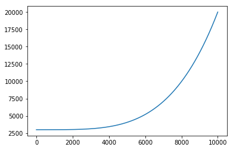

```python
pd.Series(professional_curve_ls).plot();
```

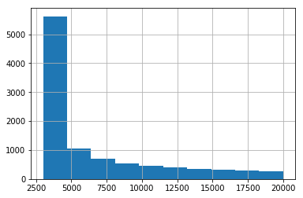

```python
pd.Series(professional_curve_ls).hist(bins=10);
```

**Superstar tier:** The simulation distributes the sellers according to the easing curve replicating a long tail (see the histogram below for more info about the expression).

```python
price_range_start = 25000
price_range_end = 100000 - price_range_start
seller_easing_function = easing.easeInQuad
```

```python
superstar_curve = map(apply_seller_distribution, seller_tiers_df.loc['superstar']['priceRangeIndexes'])
```

```python
superstar_curve_ls = list(superstar_curve)
```

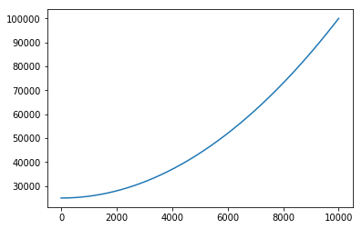

```python
pd.Series(superstar_curve_ls).plot();
```

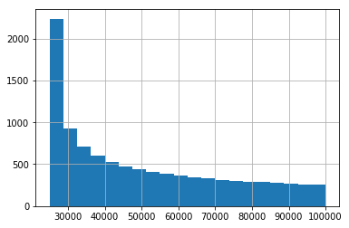

```python
pd.Series(superstar_curve_ls).hist(bins=20);
```

```python
seller_tiers_df.drop(columns={'priceRangeIndexes'}, inplace=True)
```

```python
seller_tiers_df['price'] = [professional_curve_ls, superstar_curve_ls]
```

```python
seller_tiers_df
```

| name | propension | price |
| --- | --- | --- |
| professional | 0.980 | [3000.0, 3000.000000000002, 3000.0000000000273... |
| superstar | 0.020 | [25000.0, 25000.00075, 25000.003, 25000.00675,... |

```python
seller_tiers_df['propension'].sum()
```

```
1.0
```

#### New sellers creation along the time

```python
new_sellers_dt = {
    'period' : list(pd.PeriodIndex(start='2019-09', end='2021-08', freq='M').astype(str)),
}
```

```python
new_sellers_df = pd.DataFrame(data=new_sellers_dt)
new_sellers_df.set_index('period', inplace=True)
```

```python
new_sellers_df.insert(loc=0, column='monthIndex', value=np.arange(len(new_sellers_df)))
```

The simulation uses two stages of development. First stage, after launch, using Jovem Nerd channels traction (early sellers). The second stage arises with platform popularity and seller acquisition in other channels

```python
desired_apex_month = 6
desired_cut_month = 24

desired_first_stage_curve = easing.easeInOutSine
desired_second_stage_curve = easing.easeInOutSine

desired_months = len(new_sellers_df)
desired_start = 10
desired_apex = 300
desired_estabilization = 650
```

```python
new_sellers_df.insert(
    loc=1,
    column='newSellers',
    value=new_sellers_df['monthIndex'].apply(apply_easing)
)
```

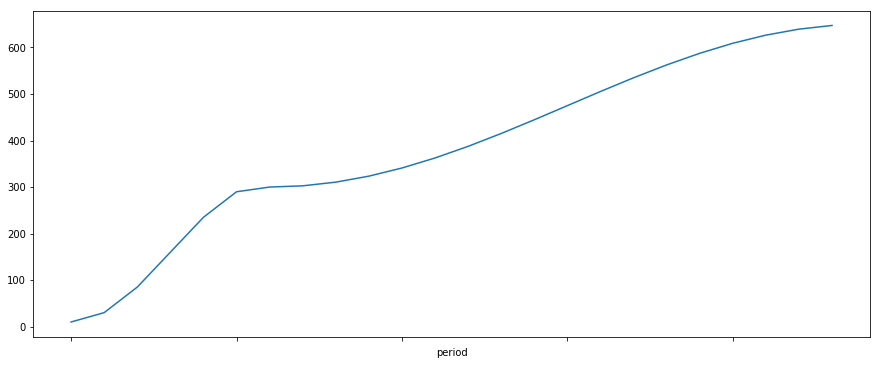

```python
new_sellers_df['newSellers'].plot(figsize=(15,6));
```

```python
new_sellers_df
```

| period | monthIndex | newSellers |
| --- | --- | --- |
| 2019-09 | 0 | 10.000 |
| 2019-10 | 1 | 30.096 |
| 2019-11 | 2 | 85.000 |
| 2019-12 | 3 | 160.000 |
| 2020-01 | 4 | 235.000 |
| 2020-02 | 5 | 289.904 |
| 2020-03 | 6 | 300.000 |
| 2020-04 | 7 | 302.659 |
| 2020-05 | 8 | 310.554 |
| 2020-06 | 9 | 323.446 |
| 2020-07 | 10 | 340.942 |
| 2020-08 | 11 | 362.512 |
| 2020-09 | 12 | 387.500 |
| 2020-10 | 13 | 415.146 |
| 2020-11 | 14 | 444.612 |
| 2020-12 | 15 | 475.000 |
| 2021-01 | 16 | 505.388 |
| 2021-02 | 17 | 534.854 |
| 2021-03 | 18 | 562.500 |
| 2021-04 | 19 | 587.488 |
| 2021-05 | 20 | 609.058 |
| 2021-06 | 21 | 626.554 |
| 2021-07 | 22 | 639.446 |
| 2021-08 | 23 | 647.341 |

```python
for row in seller_tiers_df.iterrows():
    new_sellers_df[row[0]] = new_sellers_df['newSellers'] * row[1]['propension']
    new_sellers_df[row[0]] = new_sellers_df[row[0]].round()
    new_sellers_df['{}Cumulative'.format(row[0])] = new_sellers_df[row[0]].cumsum()
```

```python
new_sellers_df['cumulative'] = new_sellers_df['newSellers'].cumsum()
```

```python
new_sellers_df
```

| period | monthIndex | newSellers | professional | professionalCumulative | superstar | superstarCumulative | cumulative |
| --- | --- | --- | --- | --- | --- | --- | --- |
| 2019-09 | 0 | 10.000 | 10.000 | 10.000 | 0.000 | 0.000 | 10.000 |
| 2019-10 | 1 | 30.096 | 29.000 | 39.000 | 1.000 | 1.000 | 40.096 |
| 2019-11 | 2 | 85.000 | 83.000 | 122.000 | 2.000 | 3.000 | 125.096 |
| 2019-12 | 3 | 160.000 | 157.000 | 279.000 | 3.000 | 6.000 | 285.096 |
| 2020-01 | 4 | 235.000 | 230.000 | 509.000 | 5.000 | 11.000 | 520.096 |
| 2020-02 | 5 | 289.904 | 284.000 | 793.000 | 6.000 | 17.000 | 810.000 |
| 2020-03 | 6 | 300.000 | 294.000 | 1087.000 | 6.000 | 23.000 | 1110.000 |
| 2020-04 | 7 | 302.659 | 297.000 | 1384.000 | 6.000 | 29.000 | 1412.659 |
| 2020-05 | 8 | 310.554 | 304.000 | 1688.000 | 6.000 | 35.000 | 1723.212 |
| 2020-06 | 9 | 323.446 | 317.000 | 2005.000 | 6.000 | 41.000 | 2046.658 |
| 2020-07 | 10 | 340.942 | 334.000 | 2339.000 | 7.000 | 48.000 | 2387.600 |
| 2020-08 | 11 | 362.512 | 355.000 | 2694.000 | 7.000 | 55.000 | 2750.112 |
| 2020-09 | 12 | 387.500 | 380.000 | 3074.000 | 8.000 | 63.000 | 3137.612 |
| 2020-10 | 13 | 415.146 | 407.000 | 3481.000 | 8.000 | 71.000 | 3552.759 |
| 2020-11 | 14 | 444.612 | 436.000 | 3917.000 | 9.000 | 80.000 | 3997.370 |
| 2020-12 | 15 | 475.000 | 466.000 | 4383.000 | 10.000 | 90.000 | 4472.370 |
| 2021-01 | 16 | 505.388 | 495.000 | 4878.000 | 10.000 | 100.000 | 4977.759 |
| 2021-02 | 17 | 534.854 | 524.000 | 5402.000 | 11.000 | 111.000 | 5512.612 |
| 2021-03 | 18 | 562.500 | 551.000 | 5953.000 | 11.000 | 122.000 | 6075.112 |
| 2021-04 | 19 | 587.488 | 576.000 | 6529.000 | 12.000 | 134.000 | 6662.600 |
| 2021-05 | 20 | 609.058 | 597.000 | 7126.000 | 12.000 | 146.000 | 7271.658 |
| 2021-06 | 21 | 626.554 | 614.000 | 7740.000 | 13.000 | 159.000 | 7898.212 |
| 2021-07 | 22 | 639.446 | 627.000 | 8367.000 | 13.000 | 172.000 | 8537.659 |
| 2021-08 | 23 | 647.341 | 634.000 | 9001.000 | 13.000 | 185.000 | 9185.000 |

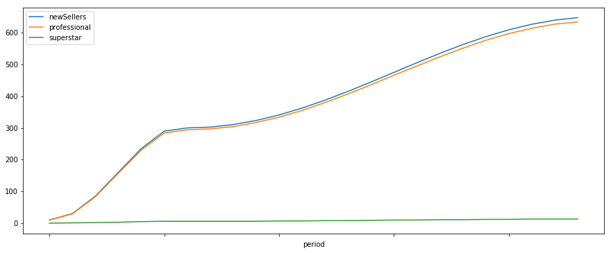

```python
new_sellers_df[['newSellers', 'professional', 'superstar']].plot(figsize=(15,6));
```

### Campaign boost

The textual analysis of the benchmark company demonstrated sazonality over campaigns, boosting sales in some months, reducing the sales in others. Below, our campaign boost along the year.

```python
campaign_boost_dt = {
    'period' : ['01', '02', '03', '04', '05', '06', '07', '08', '09', '10', '11', '12'],
    'rate': [
         0.90, # jan
         0.90, # feb
         1.00, # mar
         1.00, # apr
         1.30, # may - mães
         1.15, # jun - namorados
         1.00, # jul
         1.10, # ago - pais
         1.00, # sep
         1.05, # oct - crianças
         1.10, # nov - black friday
         1.35  # dez - natal
    ],
    'cause': [
        'Vacations',
        'Vacations',
        '-',
        '-',
        'Mother`s Day',
        'Valentine`s Day',
        '-',
        'Father`s Day',
        '-',
        'Children`s Day',
        'Black Friday',
        'Christmas and Holiday Season'
    ]
}
```

```python
campaign_boost_df = pd.DataFrame(data=campaign_boost_dt)
campaign_boost_df.set_index('period', inplace=True)
```

```python
campaign_boost_df
```

| period | rate | cause |
| --- | --- | --- |
| 01 | 0.900 | Vacations |
| 02 | 0.900 | Vacations |
| 03 | 1.000 | - |
| 04 | 1.000 | - |
| 05 | 1.300 | Mother`s Day |
| 06 | 1.150 | Valentine`s Day |
| 07 | 1.000 | - |
| 08 | 1.100 | Father`s Day |
| 09 | 1.000 | - |
| 10 | 1.050 | Children`s Day |
| 11 | 1.100 | Black Friday |
| 12 | 1.350 | Christmas and Holiday Season |

```python
new_sellers_df.transpose().to_excel('sellers.xlsx')
```

### Sellers generation

The system creates all the sellers described inside `new_sellers_df` instructions, using random prices inside the price table following the distribution tendency.

```python
if not mode_offline:

    seller_ls = []

    for period, row in new_sellers_df.iterrows():
        series = pd.Series(row)
        create_sellers(series['professional'], 'professional', period)
        create_sellers(series['superstar'], 'superstar', period)

    generated_seller_df = pd.concat(seller_ls)
    generated_seller_df.to_pickle('generated_seller.plk')

else:
    generated_seller_df = pd.read_pickle('generated_seller.plk')
```

```python
generated_seller_df.set_index('_id', inplace=True)
```

```python
generated_seller_df['createdAt'] = pd.to_datetime(generated_seller_df['createdAt'])

seller_aquisition_by_month_df = generated_seller_df["name"].groupby(
[
    generated_seller_df['createdAt'].dt.to_period("M")
]
).agg({'count'})
```

Validating the acquisition curve (the plot shape must follow the previously Sellers runway).

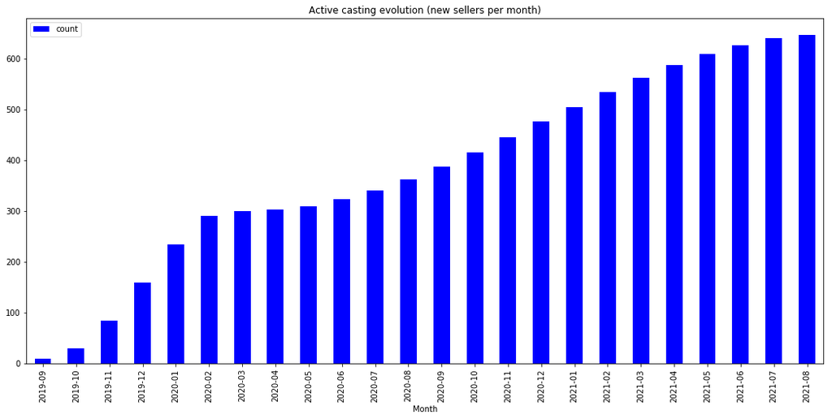

```python
fig, ax = plt.subplots()

seller_aquisition_by_month_df['count'].plot(
    kind='bar',
    title='Active casting evolution (new sellers per month)',
    figsize=(18,8),
    ax=ax,
    legend=True,
    color='blue'
)

ax.set_xlabel('Casting count')
ax.set_xlabel('Month')

plt.show()
```

### Simple price check after seller creation

Validating the price distibution of the sellers.

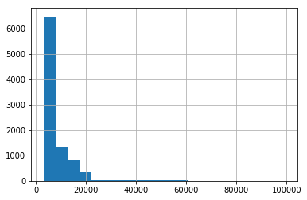

```python
generated_seller_df['price'].hist(bins=20);
```

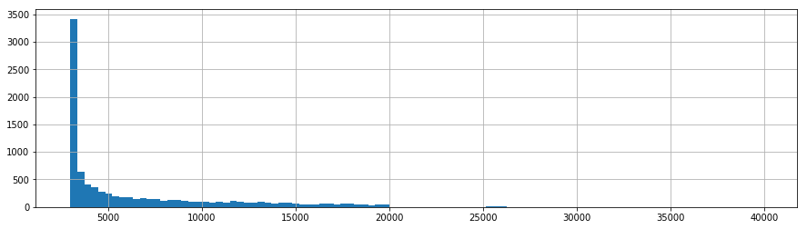

```python
generated_seller_df[generated_seller_df['price'] < 40000]['price'].hist(bins=100, figsize=(15, 4));
```

```python
generated_seller_df['price'].describe()
```

```
count    9186.000
mean     7320.496
std      8142.290
min      3000.000
25%      3074.249
50%      4250.641
75%      9018.817
max     99565.631
Name: price, dtype: float64
```

```python
len(generated_seller_df[generated_seller_df['price'] > 5000])
```

```
3994
```

```python
len(generated_seller_df[generated_seller_df['price'] < 5000])
```

```
5192
```

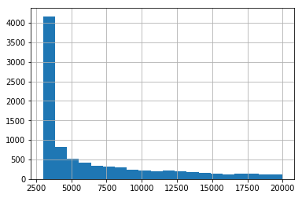

```python
generated_seller_df[generated_seller_df['tier'] == 'professional']['price'].hist(bins=20);
```

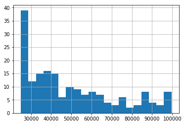

```python
generated_seller_df[generated_seller_df['tier'] == 'superstar']['price'].hist(bins=20);
```

### Order to seller rate

The order to seller rate starts using a `desired_start`, achieves the `desired_apex` using the `desired_first_stage_curve` equation. Until the simulation reaches the `desired_cut_month`, the `desired_second_stage_curve` will control the path to the `desired_estabilization`.

The early adopter sellers of benchmark platform presented an increased performance. The Jovem Nerd channels will be used at full throttle to create the initial traction and sales.

```python
order_to_seller_rate_dt = {
    'period' : list(pd.PeriodIndex(start='2019-09', end='2021-08', freq='M').astype(str))
}
```

```python
order_to_seller_rate_df = pd.DataFrame(data=order_to_seller_rate_dt)
order_to_seller_rate_df.set_index('period', inplace=True)
```

```python
order_to_seller_rate_df.insert(loc=0, column='monthIndex', value=np.arange(len(order_to_seller_rate_df)))
```

#### Professional tier

```python
desired_apex_month = 6
desired_cut_month = 14

desired_first_stage_curve = easing.easeInOutQuart
desired_second_stage_curve = easing.easeOutQuart

desired_months = len(order_to_seller_rate_df)
desired_start = 10
desired_apex = 15
desired_estabilization = 5
```

```python
order_to_seller_rate_df.insert(
    loc=1,
    column='professional',
    value=order_to_seller_rate_df['monthIndex'].apply(apply_easing)
)
```

#### Superstar tier

```python
desired_apex_month = 6
desired_cut_month = 14

desired_first_stage_curve = easing.easeInOutQuart
desired_second_stage_curve = easing.easeOutQuart

desired_months = len(order_to_seller_rate_df)
desired_start = 10
desired_apex = 15
desired_estabilization = 10
```

```python
order_to_seller_rate_df.insert(
    loc=1,
    column='superstar',
    value=order_to_seller_rate_df['monthIndex'].apply(apply_easing)
)
```

#### Consolidation

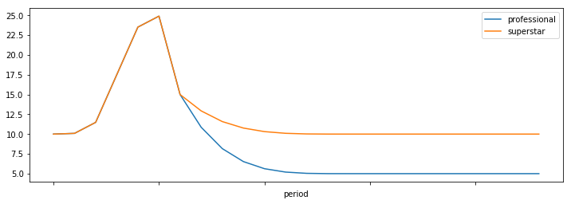

```python
order_to_seller_rate_df[['professional', 'superstar']].plot(figsize=(12, 4));
```

### Orders generation

The system generates orders for both tiers, respecting the order to sellers rate distribution along the timeline.

```python
if not mode_offline:

    order_ls = []

    for period, row in new_sellers_df.iterrows():
        series = pd.Series(row)
        create_orders(series['professionalCumulative'], 'professional', period)
        create_orders(series['superstarCumulative'], 'superstar', period)

    generated_order_df = pd.concat(order_ls)
    generated_order_df.to_pickle('generated_order.plk')

else:
    generated_order_df = pd.read_pickle('generated_order.plk')
```

```
Tier: professional, period: 2019-09, Seller count: 10.0, Campaign rate: 1.0, Rate on order_to_seller entity: 10.0, Order Count: 100.0
Tier: superstar, period: 2019-09, Seller count: 0.0, Campaign rate: 1.0, Rate on order_to_seller entity: 10.0, Order Count: 0.0
Tier: professional, period: 2019-10, Seller count: 39.0, Campaign rate: 1.05, Rate on order_to_seller entity: 10.092592592592593, Order Count: 413.29166666666674
Tier: superstar, period: 2019-10, Seller count: 1.0, Campaign rate: 1.05, Rate on order_to_seller entity: 10.092592592592593, Order Count: 10.597222222222223
Tier: professional, period: 2019-11, Seller count: 122.0, Campaign rate: 1.1, Rate on order_to_seller entity: 11.481481481481481, Order Count: 1540.8148148148148
Tier: superstar, period: 2019-11, Seller count: 3.0, Campaign rate: 1.1, Rate on order_to_seller entity: 11.481481481481481, Order Count: 37.88888888888889
Tier: professional, period: 2019-12, Seller count: 279.0, Campaign rate: 1.35, Rate on order_to_seller entity: 17.5, Order Count: 6591.375
Tier: superstar, period: 2019-12, Seller count: 6.0, Campaign rate: 1.35, Rate on order_to_seller entity: 17.5, Order Count: 141.75
Tier: professional, period: 2020-01, Seller count: 509.0, Campaign rate: 0.9, Rate on order_to_seller entity: 23.51851851851852, Order Count: 10773.833333333334
Tier: superstar, period: 2020-01, Seller count: 11.0, Campaign rate: 0.9, Rate on order_to_seller entity: 23.51851851851852, Order Count: 232.83333333333334
Tier: professional, period: 2020-02, Seller count: 793.0, Campaign rate: 0.9, Rate on order_to_seller entity: 24.907407407407405, Order Count: 17776.416666666668
Tier: superstar, period: 2020-02, Seller count: 17.0, Campaign rate: 0.9, Rate on order_to_seller entity: 24.907407407407405, Order Count: 381.0833333333333
Tier: professional, period: 2020-03, Seller count: 1087.0, Campaign rate: 1.0, Rate on order_to_seller entity: 15.0, Order Count: 16305.0
Tier: superstar, period: 2020-03, Seller count: 23.0, Campaign rate: 1.0, Rate on order_to_seller entity: 15.0, Order Count: 345.0
Tier: professional, period: 2020-04, Seller count: 1384.0, Campaign rate: 1.0, Rate on order_to_seller entity: 10.86181640625, Order Count: 15032.75390625
Tier: superstar, period: 2020-04, Seller count: 29.0, Campaign rate: 1.0, Rate on order_to_seller entity: 12.930908203125, Order Count: 374.996337890625
Tier: professional, period: 2020-05, Seller count: 1688.0, Campaign rate: 1.3, Rate on order_to_seller entity: 8.1640625, Order Count: 17915.21875
Tier: superstar, period: 2020-05, Seller count: 35.0, Campaign rate: 1.3, Rate on order_to_seller entity: 11.58203125, Order Count: 526.982421875
Tier: professional, period: 2020-06, Seller count: 2005.0, Campaign rate: 1.15, Rate on order_to_seller entity: 6.52587890625, Order Count: 15047.045288085936
Tier: superstar, period: 2020-06, Seller count: 41.0, Campaign rate: 1.15, Rate on order_to_seller entity: 10.762939453125, Order Count: 507.4725952148437
Tier: professional, period: 2020-07, Seller count: 2339.0, Campaign rate: 1.0, Rate on order_to_seller entity: 5.625, Order Count: 13156.875
Tier: superstar, period: 2020-07, Seller count: 48.0, Campaign rate: 1.0, Rate on order_to_seller entity: 10.3125, Order Count: 495.0
Tier: professional, period: 2020-08, Seller count: 2694.0, Campaign rate: 1.1, Rate on order_to_seller entity: 5.19775390625, Order Count: 15403.023925781252
Tier: superstar, period: 2020-08, Seller count: 55.0, Campaign rate: 1.1, Rate on order_to_seller entity: 10.098876953125, Order Count: 610.9820556640625
Tier: professional, period: 2020-09, Seller count: 3074.0, Campaign rate: 1.0, Rate on order_to_seller entity: 5.0390625, Order Count: 15490.078125
Tier: superstar, period: 2020-09, Seller count: 63.0, Campaign rate: 1.0, Rate on order_to_seller entity: 10.01953125, Order Count: 631.23046875
Tier: professional, period: 2020-10, Seller count: 3481.0, Campaign rate: 1.05, Rate on order_to_seller entity: 5.00244140625, Order Count: 18284.173461914062
Tier: superstar, period: 2020-10, Seller count: 71.0, Campaign rate: 1.05, Rate on order_to_seller entity: 10.001220703125, Order Count: 745.5910034179688
Tier: professional, period: 2020-11, Seller count: 3917.0, Campaign rate: 1.1, Rate on order_to_seller entity: 5.0, Order Count: 21543.5
Tier: superstar, period: 2020-11, Seller count: 80.0, Campaign rate: 1.1, Rate on order_to_seller entity: 10.0, Order Count: 880.0000000000001
Tier: professional, period: 2020-12, Seller count: 4383.0, Campaign rate: 1.35, Rate on order_to_seller entity: 5.0, Order Count: 29585.250000000004
Tier: superstar, period: 2020-12, Seller count: 90.0, Campaign rate: 1.35, Rate on order_to_seller entity: 10.0, Order Count: 1215.0
```

[output cut: 16 more lines]

```python
generated_order_df.set_index('_id', inplace=True)
```

```python
generated_order_df.head()
```

| _id | createdAt | period | consumerName | seller | tier | price | grossProfit | amountForPSP | amountForTaxes | amountForMarketplace | grossTalent | amountForTalent | amountForDonation |
| --- | --- | --- | --- | --- | --- | --- | --- | --- | --- | --- | --- | --- | --- |
| e6cfa231-9d94-4906-84cc-5b6f5fda99cf | 2019-09-01 | 2019-09 | João Pedro Farias | 956a636a-4f82-409b-8de2-b01befbac209 | professional | 3999.358 | 999.840 | 151.576 | 154.475 | 693.789 | 2999.519 | 2849.543 | 149.976 |
| 81412c05-c5dc-4783-a2e4-4bea42063e21 | 2019-09-01 | 2019-09 | Lara Cavalcanti | 6a998ae1-2aa0-4270-bcb9-fc35eb1fb71f | professional | 5092.261 | 1273.065 | 192.997 | 196.689 | 883.380 | 3819.196 | 3628.236 | 190.960 |
| 5e071257-e8ec-4409-a728-158db19ff1d8 | 2019-09-02 | 2019-09 | Murilo Lopes | 70049f5c-7c7e-4cf6-96dc-b96c576a1ea0 | professional | 3341.230 | 835.308 | 126.633 | 129.055 | 579.620 | 2505.923 | 2380.626 | 125.296 |
| d953a18c-22df-4f0c-92e4-bd945ed41332 | 2019-09-02 | 2019-09 | Carolina da Cruz | d0624aeb-f174-407e-ae4b-d090da94821b | professional | 4675.450 | 1168.862 | 177.200 | 180.589 | 811.074 | 3506.587 | 3331.258 | 175.329 |
| 15c9a93b-91a3-46d2-9424-4f2c4ec76d17 | 2019-09-02 | 2019-09 | Giovanna Almeida | 58a1359d-e53d-4290-81a1-9b1122c6c6e8 | professional | 8846.694 | 2211.674 | 335.290 | 341.704 | 1534.680 | 6635.021 | 6303.270 | 331.751 |

### Orders per tier

```python
generated_order_df[generated_order_df['tier'] == 'professional']['price'].sum()
```

```
3714037032.5351477
```

```python
generated_order_df[generated_order_df['tier'] == 'superstar']['price'].sum()
```

```
141769333.89795643
```

### Modeling

```python
generated_order_df['price'] = generated_order_df['price'] / 100
generated_order_df['grossProfit'] = generated_order_df['grossProfit'] / 100
generated_order_df['amountForPSP'] = generated_order_df['amountForPSP'] / 100
generated_order_df['amountForTaxes'] = generated_order_df['amountForTaxes'] / 100
generated_order_df['amountForMarketplace'] = generated_order_df['amountForMarketplace'] / 100
generated_order_df['grossTalent'] = generated_order_df['grossTalent'] / 100
generated_order_df['amountForTalent'] = generated_order_df['amountForTalent'] / 100
generated_order_df['amountForDonation'] = generated_order_df['amountForDonation'] / 100
```

```python
generated_order_df['createdAt'] = pd.to_datetime(generated_order_df['createdAt'])
```

```python
generated_seller_df['createdAt'] = pd.to_datetime(generated_seller_df['createdAt'])
```

```python
simulated_revenue_per_month_df = generated_order_df["price"].groupby(
    [
        generated_order_df['createdAt'].dt.to_period("M")
    ]
).agg({'sum'})
```

```python
simulated_revenue_per_month_df.rename(columns={'sum':'priceSum'}, inplace=True)
```

```python
simulated_orders_per_month_df = generated_order_df["consumerName"].groupby(
    [
        generated_order_df['createdAt'].dt.to_period("M")
    ]
).agg({'count'})
```

```python
simulated_orders_per_month_df.rename(columns={'count':'orderCount'}, inplace=True)
```

```python
simulated_amount_marketplace_per_month_df = generated_order_df["amountForMarketplace"].groupby(
    [
        generated_order_df['createdAt'].dt.to_period("M")
    ]
).agg({'sum'})
```

```python
simulated_amount_marketplace_per_month_df.rename(columns={'sum':'amountForMarketPlaceSum'}, inplace=True)
```

```python
simulated_amount_talent_per_month_df = generated_order_df["amountForTalent"].groupby(
    [
        generated_order_df['createdAt'].dt.to_period("M")
    ]
).agg({'sum'})
```

```python
simulated_amount_talent_per_month_df.rename(columns={'sum':'amountForTalentSum'}, inplace=True)
```

```python
simulated_amount_taxes_per_month_df = generated_order_df["amountForTaxes"].groupby(
    [
        generated_order_df['createdAt'].dt.to_period("M")
    ]
).agg({'sum'})
```

```python
simulated_amount_taxes_per_month_df.rename(columns={'sum':'amountForTaxesSum'}, inplace=True)
```

```python
simulated_sellers_per_month_df = generated_seller_df["name"].groupby(
    [
        generated_seller_df['createdAt'].dt.to_period("M")
    ]
).agg({'count'})
```

```python
simulated_sellers_per_month_df.rename(columns={'count':'newSellerCount'}, inplace=True)
```

```python
simulation_join_df = pd.concat([
    simulated_revenue_per_month_df,
    simulated_orders_per_month_df,
    simulated_amount_marketplace_per_month_df,
    simulated_amount_talent_per_month_df,
    simulated_amount_taxes_per_month_df,
    simulated_sellers_per_month_df
], axis=1)
```

```python
simulation_join_df['newSellerCountCumulative'] = simulation_join_df['newSellerCount'].cumsum()
```

```python
simulation_join_df['orderCountCumulative'] = simulation_join_df['orderCount'].cumsum()
```

```python
simulation_join_df['orderPerUserRate'] = simulation_join_df['orderCount'] / simulation_join_df['newSellerCountCumulative']
```

```python
simulation_join_df['companyValuation'] = (simulation_join_df['priceSum'] * 12) * 1.4
```

```python
simulation_join_df['averageTicket'] = simulation_join_df['priceSum'] / simulation_join_df['orderCount']
```

```python
simulation_join_df['revenuePerSeller'] = simulation_join_df['priceSum'] / simulation_join_df['newSellerCountCumulative']
```

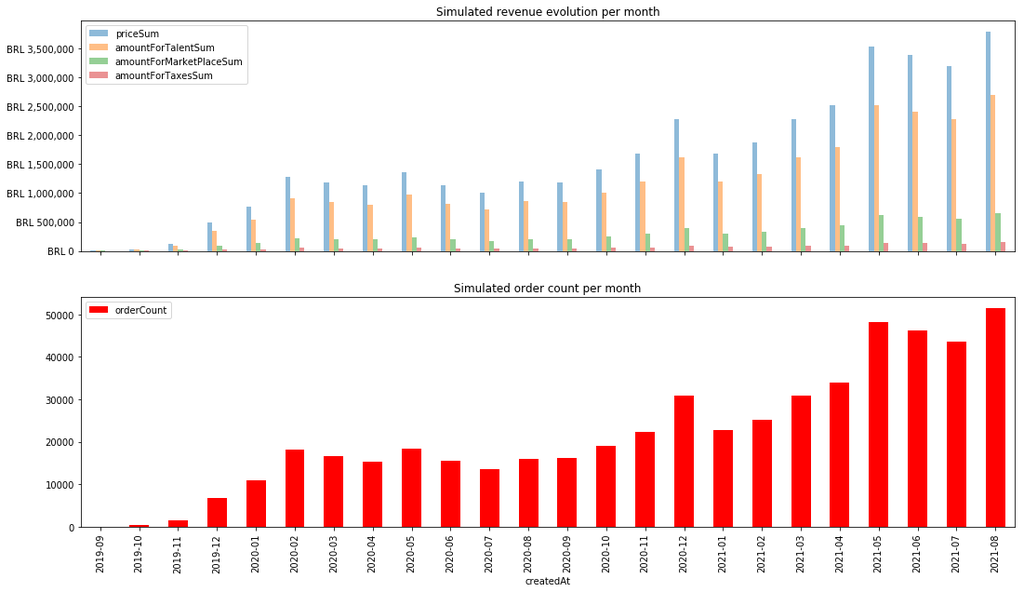

```python
fig, axarr = plt.subplots(2, sharex=True)

ax = fig.gca()

p1 = simulation_join_df[['priceSum', 'amountForTalentSum', 'amountForMarketPlaceSum', 'amountForTaxesSum']].plot(
    kind='bar',
    title='Simulated revenue evolution per month',
    figsize=(18,10),
    ax=axarr[0],
    legend=True,
    alpha=0.5
)

fmt = 'BRL {x:,.0f}'
tick = mtick.StrMethodFormatter(fmt)
axarr[0].yaxis.set_major_formatter(tick)

p2 = simulation_join_df['orderCount'].plot(
    kind='bar',
    title='Simulated order count per month',
    figsize=(18,10),
    ax=axarr[1],
    legend=True,
    color='red'
)

plt.show()
```

```python
simulation_join_df[['priceSum', 'amountForTalentSum', 'amountForMarketPlaceSum', 'amountForTaxesSum']].transpose().to_excel('prices.xlsx')
```

### Expenses

Main constant for platform expenses:

```python
average_video_bytes = 7397376
```

```python
average_thumb_bytes = 1048576
```

```python
media_samples_per_order = 2
```

```python
usd_s3_per_terabyte = 41.27
```

```python
usd_ec3_unit = 116.39
```

```python
cloud_dt = {
    'period' : list(pd.PeriodIndex(start='2019-09', end='2021-08', freq='M').astype(str)),
}
```

```python
cloud_df = pd.DataFrame(data=cloud_dt)
cloud_df.set_index('period', inplace=True)
```

```python
cloud_df['periodIndex'] = np.arange(0, len(cloud_df), 1)
```

```python
cloud_df['storageBytes'] = \
    simulation_join_df['orderCount'].values * ((average_video_bytes * media_samples_per_order) + \
                                               average_thumb_bytes)
```

```python
cloud_df['storageBytesCumulative'] = cloud_df['storageBytes'].cumsum()
```

```python
cloud_df['storageTBytes'] = cloud_df['storageBytes'] / 1024 / 1024 / 1024 / 1024
```

```python
cloud_df['storageTBytesCumulative'] = cloud_df['storageTBytes'].cumsum()
```

```python
cloud_df['storageCostUSD'] = cloud_df['storageTBytesCumulative'] * usd_s3_per_terabyte
```

```python
cloud_df['appServerCostUSD'] = usd_ec3_unit + (cloud_df['periodIndex'] * usd_ec3_unit * 0.25)
```

```python
cloud_df['cloudCostUSD'] = cloud_df['storageCostUSD'] + cloud_df['appServerCostUSD']
```

```python
cloud_df['cloudCost'] = cloud_df['cloudCostUSD'] * 4.10
```

```python
cloud_df
```

| period | periodIndex | storageBytes | storageBytesCumulative | storageTBytes | storageTBytesCumulative | storageCostUSD | appServerCostUSD | cloudCostUSD | cloudCost |
| --- | --- | --- | --- | --- | --- | --- | --- | --- | --- |
| 2019-09 | 0 | 1584332800 | 1584332800 | 0.001 | 0.001 | 0.059 | 116.390 | 116.449 | 477.443 |
| 2019-10 | 1 | 6733414400 | 8317747200 | 0.006 | 0.008 | 0.312 | 145.488 | 145.800 | 597.779 |
| 2019-11 | 2 | 25016614912 | 33334362112 | 0.023 | 0.030 | 1.251 | 174.585 | 175.836 | 720.928 |
| 2019-12 | 3 | 106688970752 | 140023332864 | 0.097 | 0.127 | 5.256 | 203.683 | 208.938 | 856.647 |
| 2020-01 | 4 | 174387511296 | 314410844160 | 0.159 | 0.286 | 11.801 | 232.780 | 244.581 | 1002.784 |
| 2020-02 | 5 | 287698993152 | 602109837312 | 0.262 | 0.548 | 22.600 | 261.877 | 284.478 | 1166.358 |
| 2020-03 | 6 | 263791411200 | 865901248512 | 0.240 | 0.788 | 32.501 | 290.975 | 323.476 | 1326.254 |
| 2020-04 | 7 | 244113997824 | 1110015246336 | 0.222 | 1.010 | 41.664 | 320.072 | 361.737 | 1483.121 |
| 2020-05 | 8 | 292198498304 | 1402213744640 | 0.266 | 1.275 | 52.632 | 349.170 | 401.802 | 1647.388 |
| 2020-06 | 9 | 246458810368 | 1648672555008 | 0.224 | 1.499 | 61.883 | 378.267 | 440.150 | 1804.616 |
| 2020-07 | 10 | 216293113856 | 1864965668864 | 0.197 | 1.696 | 70.001 | 407.365 | 477.366 | 1957.201 |
| 2020-08 | 11 | 253730897920 | 2118696566784 | 0.231 | 1.927 | 79.525 | 436.462 | 515.987 | 2115.549 |
| 2020-09 | 12 | 255441977344 | 2374138544128 | 0.232 | 2.159 | 89.113 | 465.560 | 554.673 | 2274.159 |
| 2020-10 | 13 | 301514375168 | 2675652919296 | 0.274 | 2.433 | 100.430 | 494.657 | 595.088 | 2439.860 |
| 2020-11 | 14 | 355286630400 | 3030939549696 | 0.323 | 2.757 | 113.766 | 523.755 | 637.521 | 2613.835 |
| 2020-12 | 15 | 487990345728 | 3518929895424 | 0.444 | 3.200 | 132.082 | 552.852 | 684.935 | 2808.233 |
| 2021-01 | 16 | 362035888128 | 3880965783552 | 0.329 | 3.530 | 145.671 | 581.950 | 727.621 | 2983.248 |
| 2021-02 | 17 | 400962945024 | 4281928728576 | 0.365 | 3.894 | 160.722 | 611.048 | 771.769 | 3164.253 |
| 2021-03 | 18 | 490905518080 | 4772834246656 | 0.446 | 4.341 | 179.148 | 640.145 | 819.293 | 3359.100 |
| 2021-04 | 19 | 538435502080 | 5311269748736 | 0.490 | 4.831 | 199.358 | 669.242 | 868.600 | 3561.261 |
| 2021-05 | 20 | 763917746176 | 6075187494912 | 0.695 | 5.525 | 228.031 | 698.340 | 926.371 | 3798.122 |
| 2021-06 | 21 | 734084759552 | 6809272254464 | 0.668 | 6.193 | 255.585 | 727.438 | 983.022 | 4030.392 |
| 2021-07 | 22 | 690056151040 | 7499328405504 | 0.628 | 6.821 | 281.486 | 756.535 | 1038.021 | 4255.887 |
| 2021-08 | 23 | 816596811776 | 8315925217280 | 0.743 | 7.563 | 312.137 | 785.632 | 1097.769 | 4500.855 |

```python
people_dt = {
    'period' : list(pd.PeriodIndex(start='2019-09', end='2021-08', freq='M').astype(str)),
}
```

```python
people_df = pd.DataFrame(data=people_dt)
people_df.set_index('period', inplace=True)
```

```python
people_df['periodRangeIndex'] = np.arange(0, len(people_df), 1)
```

```python
leverage_easing_start = 50000
leverage_easing_end = 130000
leverage_easing_size = len(people_df)
leverage_easing_function = easing.easeOutQuad
```

```python
people_curve = map(apply_leverage_distribution, people_df['periodRangeIndex'])
```

```python
people_curve_ls = list(people_curve)
```

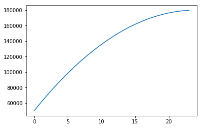

```python
pd.Series(people_curve_ls).plot();
```

```python
people_df['peopleCost'] = people_curve_ls
```

```python
people_df
```

| period | periodRangeIndex | peopleCost |
| --- | --- | --- |
| 2019-09 | 0 | 50000.000 |
| 2019-10 | 1 | 60607.639 |
| 2019-11 | 2 | 70763.889 |
| 2019-12 | 3 | 80468.750 |
| 2020-01 | 4 | 89722.222 |
| 2020-02 | 5 | 98524.306 |
| 2020-03 | 6 | 106875.000 |
| 2020-04 | 7 | 114774.306 |
| 2020-05 | 8 | 122222.222 |
| 2020-06 | 9 | 129218.750 |
| 2020-07 | 10 | 135763.889 |
| 2020-08 | 11 | 141857.639 |
| 2020-09 | 12 | 147500.000 |
| 2020-10 | 13 | 152690.972 |
| 2020-11 | 14 | 157430.556 |
| 2020-12 | 15 | 161718.750 |
| 2021-01 | 16 | 165555.556 |
| 2021-02 | 17 | 168940.972 |
| 2021-03 | 18 | 171875.000 |
| 2021-04 | 19 | 174357.639 |
| 2021-05 | 20 | 176388.889 |
| 2021-06 | 21 | 177968.750 |
| 2021-07 | 22 | 179097.222 |
| 2021-08 | 23 | 179774.306 |

```python
third_party_dt = {
    'period' : list(pd.PeriodIndex(start='2019-09', end='2021-08', freq='M').astype(str)),
    'thirdPartyCost': [
        10000,
        10000,
        10000,
        10000,
        10000,
        10000,
        20000,
        20000,
        20000,
        20000,
        20000,
        20000,
        25000,
        25000,
        25000,
        25000,
        25000,
        25000,
        30000,
        30000,
        30000,
        30000,
        30000,
        30000,
    ]
}
```

```python
third_party_df = pd.DataFrame(data=third_party_dt)
third_party_df.set_index('period', inplace=True)
```

```python
third_party_df
```

| period | thirdPartyCost |
| --- | --- |
| 2019-09 | 10000 |
| 2019-10 | 10000 |
| 2019-11 | 10000 |
| 2019-12 | 10000 |
| 2020-01 | 10000 |
| 2020-02 | 10000 |
| 2020-03 | 20000 |
| 2020-04 | 20000 |
| 2020-05 | 20000 |
| 2020-06 | 20000 |
| 2020-07 | 20000 |
| 2020-08 | 20000 |
| 2020-09 | 25000 |
| 2020-10 | 25000 |
| 2020-11 | 25000 |
| 2020-12 | 25000 |
| 2021-01 | 25000 |
| 2021-02 | 25000 |
| 2021-03 | 30000 |
| 2021-04 | 30000 |
| 2021-05 | 30000 |
| 2021-06 | 30000 |
| 2021-07 | 30000 |
| 2021-08 | 30000 |

```python
g_and_a_dt = {
    'period' : list(pd.PeriodIndex(start='2019-09', end='2021-08', freq='M').astype(str)),
}
```

```python
g_and_a_df = pd.DataFrame(data=g_and_a_dt)
g_and_a_df.set_index('period', inplace=True)
```

```python
g_and_a_df['periodRangeIndex'] = np.arange(0, len(g_and_a_df), 1)
```

```python
leverage_easing_start = 20000
leverage_easing_end = 30000
leverage_easing_size = len(g_and_a_df)
leverage_easing_function = easing.easeOutQuad
```

```python
g_and_a_curve = map(apply_leverage_distribution, g_and_a_df['periodRangeIndex'])
```

```python
g_and_a_curve_ls = list(g_and_a_curve)
```

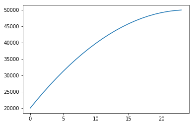

```python
pd.Series(g_and_a_curve_ls).plot();
```

```python
g_and_a_df['gAndACost'] = g_and_a_curve_ls
```

```python
g_and_a_df
```

| period | periodRangeIndex | gAndACost |
| --- | --- | --- |
| 2019-09 | 0 | 20000.000 |
| 2019-10 | 1 | 22447.917 |
| 2019-11 | 2 | 24791.667 |
| 2019-12 | 3 | 27031.250 |
| 2020-01 | 4 | 29166.667 |
| 2020-02 | 5 | 31197.917 |
| 2020-03 | 6 | 33125.000 |
| 2020-04 | 7 | 34947.917 |
| 2020-05 | 8 | 36666.667 |
| 2020-06 | 9 | 38281.250 |
| 2020-07 | 10 | 39791.667 |
| 2020-08 | 11 | 41197.917 |
| 2020-09 | 12 | 42500.000 |
| 2020-10 | 13 | 43697.917 |
| 2020-11 | 14 | 44791.667 |
| 2020-12 | 15 | 45781.250 |
| 2021-01 | 16 | 46666.667 |
| 2021-02 | 17 | 47447.917 |
| 2021-03 | 18 | 48125.000 |
| 2021-04 | 19 | 48697.917 |
| 2021-05 | 20 | 49166.667 |
| 2021-06 | 21 | 49531.250 |
| 2021-07 | 22 | 49791.667 |
| 2021-08 | 23 | 49947.917 |

```python
cost_acquisition_dt = {
    'period' : list(pd.PeriodIndex(start='2019-09', end='2021-08', freq='M').astype(str)),
}
```

```python
cost_acquisition_df = pd.DataFrame(data=cost_acquisition_dt)
cost_acquisition_df.set_index('period', inplace=True)
```

#### Seller CAC

```python
cost_acquisition_df['sellerAcquisitionCostFromRevenue'] = \
    simulation_join_df['amountForMarketPlaceSum'].values * seller_cac_from_marketplace_amount
```

```python
cost_acquisition_df['periodRangeIndex'] = np.arange(0, len(cost_acquisition_df), 1)
```

```python
leverage_easing_start = 20000
leverage_easing_end = -20000
leverage_easing_size = len(cost_acquisition_df)
leverage_easing_function = easing.easeOutQuad
```

```python
seller_acquisition_subsidizy_curve = map(apply_leverage_distribution, cost_acquisition_df['periodRangeIndex'])
```

```python
seller_acquisition_subsidizy_curve_ls = list(seller_acquisition_subsidizy_curve)
```

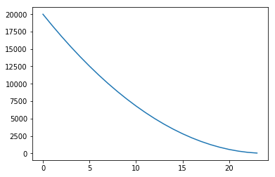

```python
pd.Series(seller_acquisition_subsidizy_curve_ls).plot();
```

```python
cost_acquisition_df['sellerAcquisitionCostSubsidized'] = seller_acquisition_subsidizy_curve_ls
```

```python
cost_acquisition_df['sellerAcquisitionCost'] = \
    cost_acquisition_df['sellerAcquisitionCostFromRevenue'] + cost_acquisition_df['sellerAcquisitionCostSubsidized']
```

#### Customer CAC

```python
cost_acquisition_df['customerAcquisitionCostFromRevenue'] = \
    simulation_join_df['amountForMarketPlaceSum'].values * customer_cac_from_marketplace_amount
```

```python
cost_acquisition_df['customerAcquisitionCost'] = cost_acquisition_df['customerAcquisitionCostFromRevenue']
```

```python
expenses_join_df = pd.concat([
    cloud_df,
    people_df,
    third_party_df,
    g_and_a_df,
    cost_acquisition_df
], axis=1)
```

```python
expenses_join_df['cloudCostCumulative'] = expenses_join_df['cloudCost'].cumsum()
expenses_join_df['peopleCostCumulative'] = expenses_join_df['peopleCost'].cumsum()
expenses_join_df['thirdPartyCostCumulative'] = expenses_join_df['thirdPartyCost'].cumsum()
expenses_join_df['gAndACostCumulative'] = expenses_join_df['gAndACost'].cumsum()
expenses_join_df['sellerAcquisitionCostCumulative'] = expenses_join_df['sellerAcquisitionCost'].cumsum()
expenses_join_df['customerAcquisitionCostCumulative'] = expenses_join_df['customerAcquisitionCost'].cumsum()
```

```python
expenses_join_df['sumCost'] = \
    expenses_join_df['cloudCost'] + \
    expenses_join_df['peopleCost'] + \
    expenses_join_df['thirdPartyCost'] + \
    expenses_join_df['gAndACost'] + \
    expenses_join_df['sellerAcquisitionCost'] + \
    expenses_join_df['customerAcquisitionCost']
```

```python
expenses_join_df['sumCostCumulative'] = expenses_join_df['sumCost'].cumsum()
```

```python
simulation_join_df['sumCost'] = expenses_join_df['sumCost'].values
simulation_join_df['sumCostCumulative'] = expenses_join_df['sumCostCumulative'].values
```

```python
simulation_join_df['balance'] = simulation_join_df['amountForMarketPlaceSum'] - simulation_join_df['sumCost']
```

```python
# funds = 1660000
```

```python
funds = 2000000
```

```python
def calculate_funds(period):
    global funds

    # print('Balance (period): {}'.format(period))
    funds = funds + period
    # print('Funds: {} \n \n'.format(funds))

    return funds
```

```python
simulation_join_df['funds'] = simulation_join_df['balance'].apply(calculate_funds)
```

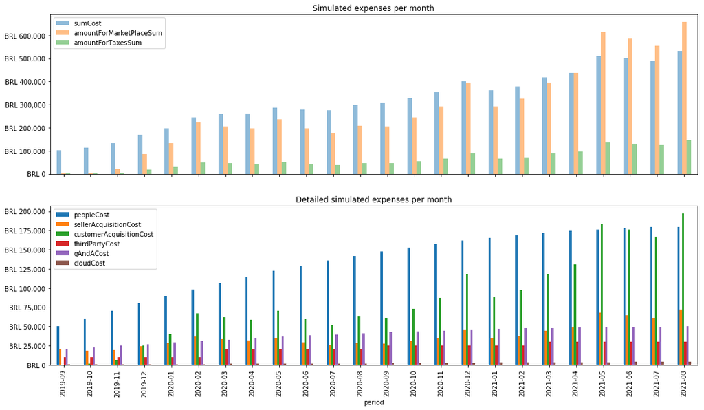

```python
fig, axarr = plt.subplots(2, sharex=True)

ax = fig.gca()

p1 = simulation_join_df[['sumCost', 'amountForMarketPlaceSum', 'amountForTaxesSum']].plot(
    kind='bar',
    title='Simulated expenses per month',
    figsize=(18,10),
    ax=axarr[0],
    legend=True,
    alpha=0.5
)

fmt = 'BRL {x:,.0f}'
tick = mtick.StrMethodFormatter(fmt)
axarr[0].yaxis.set_major_formatter(tick)

p2 = expenses_join_df[['peopleCost', 'sellerAcquisitionCost', 'customerAcquisitionCost', 'thirdPartyCost', 'gAndACost', 'cloudCost']].plot(
    kind='bar',
    title='Detailed simulated expenses per month',
    figsize=(18,10),
    ax=axarr[1],
    legend=True
)

axarr[1].yaxis.set_major_formatter(tick)

plt.show()
```

```python
expenses_join_df[['peopleCost', 'sellerAcquisitionCost', 'customerAcquisitionCost', 'thirdPartyCost', 'gAndACost', 'cloudCost']].transpose().to_excel('expenses.xlsx')
```

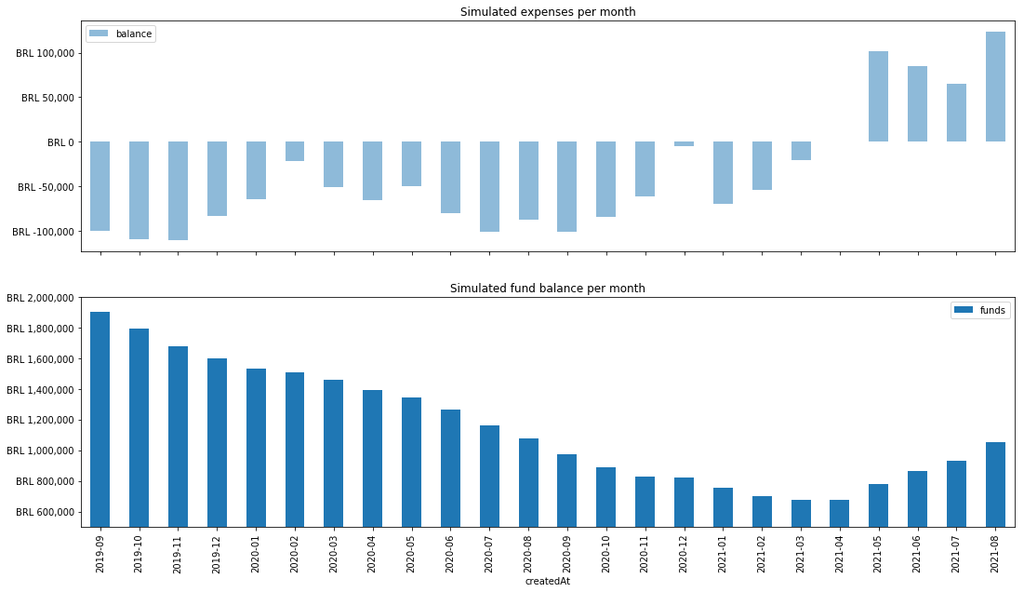

```python
fig, axarr = plt.subplots(2, sharex=True)

ax = fig.gca()

p1 = simulation_join_df[['balance']].plot(
    kind='bar',
    title='Simulated expenses per month',
    figsize=(18,10),
    ax=axarr[0],
    legend=True,
    alpha=0.5
)

fmt = 'BRL {x:,.0f}'
tick = mtick.StrMethodFormatter(fmt)
axarr[0].yaxis.set_major_formatter(tick)

p2 = simulation_join_df[['funds']].plot(
    kind='bar',
    title='Simulated fund balance per month',
    figsize=(18,10),
    ax=axarr[1],
    legend=True,
    ylim=(500000, 2000000)
)

axarr[1].yaxis.set_major_formatter(tick)

plt.show()
```

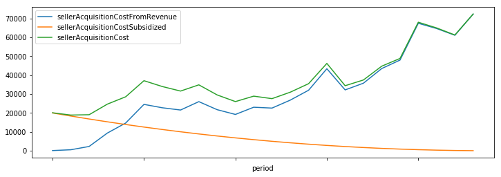

```python
expenses_join_df[['sellerAcquisitionCostFromRevenue', 'sellerAcquisitionCostSubsidized', 'sellerAcquisitionCost']].plot(figsize=(12,4));
```

```python
expenses_join_df
```

| period | periodIndex | storageBytes | storageBytesCumulative | storageTBytes | storageTBytesCumulative | storageCostUSD | appServerCostUSD | cloudCostUSD | cloudCost | periodRangeIndex | ... | customerAcquisitionCostFromRevenue | customerAcquisitionCost | cloudCostCumulative | peopleCostCumulative | thirdPartyCostCumulative | gAndACostCumulative | sellerAcquisitionCostCumulative | customerAcquisitionCostCumulative | sumCost | sumCostCumulative |
| --- | --- | --- | --- | --- | --- | --- | --- | --- | --- | --- | --- | --- | --- | --- | --- | --- | --- | --- | --- | --- | --- |
| 2019-09 | 0 | 1584332800 | 1584332800 | 0.001 | 0.001 | 0.059 | 116.390 | 116.449 | 477.443 | 0 | ... | 267.700 | 267.700 | 477.443 | 50000.000 | 10000 | 20000.000 | 20098.157 | 267.700 | 100843.300 | 100843.300 |
| 2019-10 | 1 | 6733414400 | 8317747200 | 0.006 | 0.008 | 0.312 | 145.488 | 145.800 | 597.779 | 1 | ... | 1409.999 | 1409.999 | 1075.222 | 110607.639 | 20000 | 42447.917 | 38983.212 | 1677.699 | 113948.388 | 214791.688 |
| 2019-11 | 2 | 25016614912 | 33334362112 | 0.023 | 0.030 | 1.251 | 174.585 | 175.836 | 720.928 | 2 | ... | 6164.673 | 6164.673 | 1796.150 | 181371.528 | 30000 | 67239.583 | 58049.148 | 7842.373 | 131507.093 | 346298.782 |
| 2019-12 | 3 | 106688970752 | 140023332864 | 0.097 | 0.127 | 5.256 | 203.683 | 208.938 | 856.647 | 3 | ... | 25553.226 | 25553.226 | 2652.797 | 261840.278 | 40000 | 94270.833 | 82731.164 | 33395.599 | 168591.889 | 514890.671 |
| 2020-01 | 4 | 174387511296 | 314410844160 | 0.159 | 0.286 | 11.801 | 232.780 | 244.581 | 1002.784 | 4 | ... | 40020.259 | 40020.259 | 3655.580 | 351562.500 | 50000 | 123437.500 | 111294.148 | 73415.858 | 198474.915 | 713365.586 |
| 2020-02 | 5 | 287698993152 | 602109837312 | 0.262 | 0.548 | 22.600 | 261.877 | 284.478 | 1166.358 | 5 | ... | 66939.971 | 66939.971 | 4821.939 | 450086.806 | 60000 | 154635.417 | 148373.526 | 140355.829 | 244907.930 | 958273.517 |
| 2020-03 | 6 | 263791411200 | 865901248512 | 0.240 | 0.788 | 32.501 | 290.975 | 323.476 | 1326.254 | 6 | ... | 62048.395 | 62048.395 | 6148.192 | 556961.806 | 80000 | 187760.417 | 182374.604 | 202404.224 | 257375.726 | 1215649.243 |
| 2020-04 | 7 | 244113997824 | 1110015246336 | 0.222 | 1.010 | 41.664 | 320.072 | 361.737 | 1483.121 | 7 | ... | 58783.742 | 58783.742 | 7631.313 | 671736.111 | 100000 | 222708.333 | 213963.365 | 261187.966 | 261577.846 | 1477227.089 |
| 2020-05 | 8 | 292198498304 | 1402213744640 | 0.266 | 1.275 | 52.632 | 349.170 | 401.802 | 1647.388 | 8 | ... | 70898.867 | 70898.867 | 9278.701 | 793958.333 | 120000 | 259375.000 | 248848.505 | 332086.833 | 286320.283 | 1763547.372 |
| 2020-06 | 9 | 246458810368 | 1648672555008 | 0.224 | 1.499 | 61.883 | 378.267 | 440.150 | 1804.616 | 9 | ... | 59293.321 | 59293.321 | 11083.316 | 923177.083 | 140000 | 297656.250 | 278401.890 | 391380.153 | 278151.320 | 2041698.693 |
| 2020-07 | 10 | 216293113856 | 1864965668864 | 0.197 | 1.696 | 70.001 | 407.365 | 477.366 | 1957.201 | 10 | ... | 52414.395 | 52414.395 | 13040.518 | 1058940.972 | 160000 | 337447.917 | 304426.057 | 443794.549 | 275951.319 | 2317650.012 |
| 2020-08 | 11 | 253730897920 | 2118696566784 | 0.231 | 1.927 | 79.525 | 436.462 | 515.987 | 2115.549 | 11 | ... | 62824.281 | 62824.281 | 15156.066 | 1200798.611 | 180000 | 378645.833 | 333329.682 | 506618.830 | 296899.011 | 2614549.022 |
| 2020-09 | 12 | 255441977344 | 2374138544128 | 0.232 | 2.159 | 89.113 | 465.560 | 554.673 | 2274.159 | 12 | ... | 61579.289 | 61579.289 | 17430.225 | 1348298.611 | 205000 | 421145.833 | 360908.755 | 568198.119 | 306432.520 | 2920981.543 |
| 2020-10 | 13 | 301514375168 | 2675652919296 | 0.274 | 2.433 | 100.430 | 494.657 | 595.088 | 2439.860 | 13 | ... | 73087.816 | 73087.816 | 19870.085 | 1500989.583 | 230000 | 464843.750 | 391909.009 | 641285.935 | 327916.819 | 3248898.362 |
| 2020-11 | 14 | 355286630400 | 3030939549696 | 0.323 | 2.757 | 113.766 | 523.755 | 637.521 | 2613.835 | 14 | ... | 87344.029 | 87344.029 | 22483.920 | 1658420.139 | 255000 | 509635.417 | 427407.375 | 728629.963 | 352678.452 | 3601576.815 |
| 2020-12 | 15 | 487990345728 | 3518929895424 | 0.444 | 3.200 | 132.082 | 552.852 | 684.935 | 2808.233 | 15 | ... | 118417.448 | 118417.448 | 25292.154 | 1820138.889 | 280000 | 555416.667 | 473639.606 | 847047.411 | 399957.912 | 4001534.727 |
| 2021-01 | 16 | 362035888128 | 3880965783552 | 0.329 | 3.530 | 145.671 | 581.950 | 727.621 | 2983.248 | 16 | ... | 87831.891 | 87831.891 | 28275.402 | 1985694.444 | 305000 | 602083.333 | 508066.855 | 934879.302 | 362464.611 | 4363999.337 |
| 2021-02 | 17 | 400962945024 | 4281928728576 | 0.365 | 3.894 | 160.722 | 611.048 | 771.769 | 3164.253 | 17 | ... | 97539.509 | 97539.509 | 31439.655 | 2154635.417 | 330000 | 649531.250 | 545532.731 | 1032418.811 | 379558.526 | 4743557.863 |
| 2021-03 | 18 | 490905518080 | 4772834246656 | 0.446 | 4.341 | 179.148 | 640.145 | 819.293 | 3359.100 | 18 | ... | 118685.631 | 118685.631 | 34798.754 | 2326510.417 | 360000 | 697656.250 | 590300.796 | 1151104.442 | 416812.796 | 5160370.659 |
| 2021-04 | 19 | 538435502080 | 5311269748736 | 0.490 | 4.831 | 199.358 | 669.242 | 868.600 | 3561.261 | 19 | ... | 130914.047 | 130914.047 | 38360.015 | 2500868.056 | 390000 | 746354.167 | 639170.668 | 1282018.490 | 436400.737 | 5596771.396 |
| 2021-05 | 20 | 763917746176 | 6075187494912 | 0.695 | 5.525 | 228.031 | 698.340 | 926.371 | 3798.122 | 20 | ... | 184057.699 | 184057.699 | 42158.137 | 2677256.944 | 420000 | 795520.833 | 707214.047 | 1466076.189 | 511454.756 | 6108226.151 |
| 2021-06 | 21 | 734084759552 | 6809272254464 | 0.668 | 6.193 | 255.585 | 727.438 | 983.022 | 4030.392 | 21 | ... | 176483.269 | 176483.269 | 46188.530 | 2855225.694 | 450000 | 845052.083 | 772237.079 | 1642559.458 | 503036.693 | 6611262.844 |
| 2021-07 | 22 | 690056151040 | 7499328405504 | 0.628 | 6.821 | 281.486 | 756.535 | 1038.021 | 4255.887 | 22 | ... | 166748.114 | 166748.114 | 50444.416 | 3034322.917 | 480000 | 894843.750 | 833516.943 | 1809307.572 | 491172.754 | 7102435.598 |
| 2021-08 | 23 | 816596811776 | 8315925217280 | 0.743 | 7.563 | 312.137 | 785.632 | 1097.769 | 4500.855 | 23 | ... | 197350.456 | 197350.456 | 54945.271 | 3214097.222 | 510000 | 944791.667 | 905913.499 | 2006658.028 | 533970.089 | 7636405.687 |

24 rows × 28 columns

```python
simulation_join_df.transpose().to_excel('balance.xlsx')
```

```python
simulation_join_df['priceSumCumulative'] = simulation_join_df['priceSum'].cumsum()
```

```python
simulation_join_df
```

| createdAt | priceSum | orderCount | amountForMarketPlaceSum | amountForTalentSum | amountForTaxesSum | newSellerCount | newSellerCountCumulative | orderCountCumulative | orderPerUserRate | companyValuation | averageTicket | revenuePerSeller | sumCost | sumCostCumulative | balance | funds | priceSumCumulative |
| --- | --- | --- | --- | --- | --- | --- | --- | --- | --- | --- | --- | --- | --- | --- | --- | --- | --- |
| 2019-09 | 5143.879 | 100 | 892.334 | 3665.014 | 198.682 | 10 | 10 | 100 | 10.000 | 86417.170 | 51.439 | 514.388 | 100843.300 | 100843.300 | -99950.965 | 1900049.035 | 5143.879 |
| 2019-10 | 27093.219 | 425 | 4699.996 | 19303.918 | 1046.476 | 30 | 40 | 525 | 10.625 | 455166.078 | 63.749 | 677.330 | 113948.388 | 214791.688 | -109248.392 | 1790800.642 | 32237.098 |
| 2019-11 | 118454.600 | 1579 | 20548.912 | 84398.902 | 4575.309 | 85 | 125 | 2104 | 12.632 | 1990037.272 | 75.019 | 947.637 | 131507.093 | 346298.782 | -110958.182 | 1679842.461 | 150691.698 |
| 2019-12 | 491006.895 | 6734 | 85177.421 | 349842.413 | 18965.141 | 160 | 285 | 8838 | 23.628 | 8248915.836 | 72.915 | 1722.831 | 168591.889 | 514890.671 | -83414.468 | 1596427.992 | 641698.593 |
| 2020-01 | 768991.863 | 11007 | 133400.863 | 547906.703 | 29702.311 | 235 | 520 | 19845 | 21.167 | 12919063.304 | 69.864 | 1478.831 | 198474.915 | 713365.586 | -65074.052 | 1531353.940 | 1410690.456 |
| 2020-02 | 1286255.875 | 18159 | 223133.238 | 916457.311 | 49681.633 | 290 | 810 | 38004 | 22.419 | 21609098.704 | 70.833 | 1587.970 | 244907.930 | 958273.517 | -21774.692 | 1509579.248 | 2696946.331 |
| 2020-03 | 1192263.913 | 16650 | 206827.982 | 849488.038 | 46051.194 | 300 | 1110 | 54654 | 15.000 | 20030033.730 | 71.607 | 1074.112 | 257375.726 | 1215649.243 | -50547.744 | 1459031.504 | 3889210.244 |
| 2020-04 | 1129533.404 | 15408 | 195945.807 | 804792.550 | 43628.228 | 303 | 1413 | 70062 | 10.904 | 18976161.183 | 73.308 | 799.387 | 261577.846 | 1477227.089 | -65632.039 | 1393399.465 | 5018743.647 |
| 2020-05 | 1362326.304 | 18443 | 236329.556 | 970657.491 | 52619.853 | 310 | 1723 | 88505 | 10.704 | 22887081.902 | 73.867 | 790.671 | 286320.283 | 1763547.372 | -49990.728 | 1343408.738 | 6381069.951 |
| 2020-06 | 1139324.986 | 15556 | 197644.402 | 811769.052 | 44006.428 | 323 | 2046 | 104061 | 7.603 | 19140659.757 | 73.240 | 556.855 | 278151.320 | 2041698.693 | -80506.919 | 1262901.819 | 7520394.937 |
| 2020-07 | 1007145.988 | 13652 | 174714.650 | 717591.517 | 38901.014 | 341 | 2387 | 117713 | 5.719 | 16920052.606 | 73.773 | 421.930 | 275951.319 | 2317650.012 | -101236.669 | 1161665.150 | 8527540.925 |
| 2020-08 | 1207172.621 | 16015 | 209414.271 | 860110.493 | 46627.043 | 362 | 2749 | 133728 | 5.826 | 20280500.040 | 75.378 | 439.132 | 296899.011 | 2614549.022 | -87484.740 | 1074180.410 | 9734713.547 |
| 2020-09 | 1183250.014 | 16123 | 205264.296 | 843065.635 | 45703.032 | 388 | 3137 | 149851 | 5.140 | 19878600.229 | 73.389 | 377.192 | 306432.520 | 2920981.543 | -101168.224 | 973012.186 | 10917963.560 |
| 2020-10 | 1404387.107 | 19031 | 243626.053 | 1000625.814 | 54244.452 | 415 | 3552 | 168882 | 5.358 | 23593703.403 | 73.795 | 395.379 | 327916.819 | 3248898.362 | -84290.766 | 888721.420 | 12322350.667 |
| 2020-11 | 1678321.153 | 22425 | 291146.762 | 1195803.822 | 64825.155 | 445 | 3997 | 191307 | 5.610 | 28195795.374 | 74.842 | 419.895 | 352678.452 | 3601576.815 | -61531.690 | 827189.730 | 14000671.821 |
| 2020-12 | 2275398.909 | 30801 | 394724.826 | 1621221.722 | 87887.283 | 476 | 4473 | 222108 | 6.886 | 38226701.666 | 73.874 | 508.696 | 399957.912 | 4001534.727 | -5233.086 | 821956.643 | 16276070.729 |
| 2021-01 | 1687695.468 | 22851 | 292772.971 | 1202483.021 | 65187.237 | 505 | 4978 | 244959 | 4.590 | 28353283.866 | 73.857 | 339.031 | 362464.611 | 4363999.337 | -69691.639 | 752265.004 | 17963766.198 |
| 2021-02 | 1874227.960 | 25308 | 325131.695 | 1335387.421 | 72392.055 | 535 | 5513 | 270267 | 4.591 | 31487029.725 | 74.057 | 339.965 | 379558.526 | 4743557.863 | -54426.831 | 697838.173 | 19837994.157 |
| 2021-03 | 2280552.076 | 30985 | 395618.771 | 1624893.354 | 88086.324 | 562 | 6075 | 301252 | 5.100 | 38313274.878 | 73.602 | 375.400 | 416812.796 | 5160370.659 | -21194.025 | 676644.149 | 22118546.234 |
| 2021-04 | 2515521.877 | 33985 | 436380.158 | 1792309.337 | 97162.032 | 588 | 6663 | 335237 | 5.101 | 42260767.533 | 74.019 | 377.536 | 436400.737 | 5596771.396 | -20.579 | 676623.570 | 24634068.110 |
| 2021-05 | 3536680.587 | 48217 | 613525.665 | 2519884.918 | 136604.288 | 609 | 7272 | 383454 | 6.631 | 59416233.859 | 73.349 | 486.342 | 511454.756 | 6108226.151 | 102070.909 | 778694.479 | 28170748.697 |
| 2021-06 | 3391137.417 | 46334 | 588277.563 | 2416185.410 | 130982.683 | 627 | 7899 | 429788 | 5.866 | 56971108.609 | 73.189 | 429.312 | 503036.693 | 6611262.844 | 85240.870 | 863935.349 | 31561886.115 |
| 2021-07 | 3204075.788 | 43555 | 555827.047 | 2282903.999 | 123757.427 | 640 | 8539 | 473343 | 5.101 | 53828473.246 | 73.564 | 375.228 | 491172.754 | 7102435.598 | 64654.294 | 928589.643 | 34765961.903 |
| 2021-08 | 3792101.761 | 51542 | 657834.853 | 2701872.505 | 146469.931 | 647 | 9186 | 524885 | 5.611 | 63707309.590 | 73.573 | 412.813 | 533970.089 | 7636405.687 | 123864.764 | 1052454.407 | 38558063.664 |

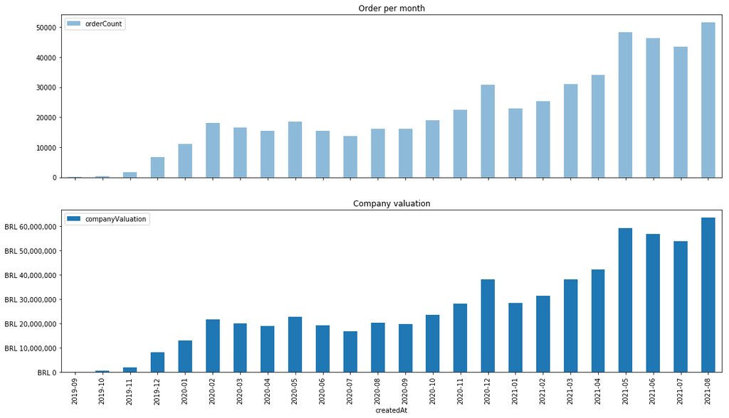

```python
fig, axarr = plt.subplots(2, sharex=True)

ax = fig.gca()

p1 = simulation_join_df[['orderCount']].plot(
    kind='bar',
    title='Order per month',
    figsize=(18,10),
    ax=axarr[0],
    legend=True,
    alpha=0.5
)

fmt = 'BRL {x:,.0f}'
tick = mtick.StrMethodFormatter(fmt)

p2 = simulation_join_df[['companyValuation']].plot(
    kind='bar',
    title='Company valuation',
    figsize=(18,10),
    ax=axarr[1],
    legend=True
)

axarr[1].yaxis.set_major_formatter(tick)

plt.show()
```

```python
simulation_join_df[['newSellerCount', 'newSellerCountCumulative', 'orderPerUserRate', 'revenuePerSeller', 'averageTicket', 'priceSum', 'amountForMarketPlaceSum', 'companyValuation']]
```

| createdAt | newSellerCount | newSellerCountCumulative | orderPerUserRate | revenuePerSeller | averageTicket | priceSum | amountForMarketPlaceSum | companyValuation |
| --- | --- | --- | --- | --- | --- | --- | --- | --- |
| 2019-09 | 10 | 10 | 10.000 | 514.388 | 51.439 | 5143.879 | 892.334 | 86417.170 |
| 2019-10 | 30 | 40 | 10.625 | 677.330 | 63.749 | 27093.219 | 4699.996 | 455166.078 |
| 2019-11 | 85 | 125 | 12.632 | 947.637 | 75.019 | 118454.600 | 20548.912 | 1990037.272 |
| 2019-12 | 160 | 285 | 23.628 | 1722.831 | 72.915 | 491006.895 | 85177.421 | 8248915.836 |
| 2020-01 | 235 | 520 | 21.167 | 1478.831 | 69.864 | 768991.863 | 133400.863 | 12919063.304 |
| 2020-02 | 290 | 810 | 22.419 | 1587.970 | 70.833 | 1286255.875 | 223133.238 | 21609098.704 |
| 2020-03 | 300 | 1110 | 15.000 | 1074.112 | 71.607 | 1192263.913 | 206827.982 | 20030033.730 |
| 2020-04 | 303 | 1413 | 10.904 | 799.387 | 73.308 | 1129533.404 | 195945.807 | 18976161.183 |
| 2020-05 | 310 | 1723 | 10.704 | 790.671 | 73.867 | 1362326.304 | 236329.556 | 22887081.902 |
| 2020-06 | 323 | 2046 | 7.603 | 556.855 | 73.240 | 1139324.986 | 197644.402 | 19140659.757 |
| 2020-07 | 341 | 2387 | 5.719 | 421.930 | 73.773 | 1007145.988 | 174714.650 | 16920052.606 |
| 2020-08 | 362 | 2749 | 5.826 | 439.132 | 75.378 | 1207172.621 | 209414.271 | 20280500.040 |
| 2020-09 | 388 | 3137 | 5.140 | 377.192 | 73.389 | 1183250.014 | 205264.296 | 19878600.229 |
| 2020-10 | 415 | 3552 | 5.358 | 395.379 | 73.795 | 1404387.107 | 243626.053 | 23593703.403 |
| 2020-11 | 445 | 3997 | 5.610 | 419.895 | 74.842 | 1678321.153 | 291146.762 | 28195795.374 |
| 2020-12 | 476 | 4473 | 6.886 | 508.696 | 73.874 | 2275398.909 | 394724.826 | 38226701.666 |
| 2021-01 | 505 | 4978 | 4.590 | 339.031 | 73.857 | 1687695.468 | 292772.971 | 28353283.866 |
| 2021-02 | 535 | 5513 | 4.591 | 339.965 | 74.057 | 1874227.960 | 325131.695 | 31487029.725 |
| 2021-03 | 562 | 6075 | 5.100 | 375.400 | 73.602 | 2280552.076 | 395618.771 | 38313274.878 |
| 2021-04 | 588 | 6663 | 5.101 | 377.536 | 74.019 | 2515521.877 | 436380.158 | 42260767.533 |
| 2021-05 | 609 | 7272 | 6.631 | 486.342 | 73.349 | 3536680.587 | 613525.665 | 59416233.859 |
| 2021-06 | 627 | 7899 | 5.866 | 429.312 | 73.189 | 3391137.417 | 588277.563 | 56971108.609 |
| 2021-07 | 640 | 8539 | 5.101 | 375.228 | 73.564 | 3204075.788 | 555827.047 | 53828473.246 |
| 2021-08 | 647 | 9186 | 5.611 | 412.813 | 73.573 | 3792101.761 | 657834.853 | 63707309.590 |

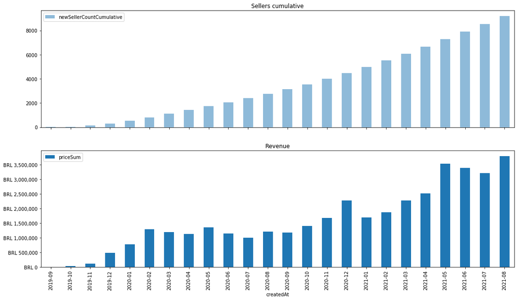

```python
fig, axarr = plt.subplots(2, sharex=True)

ax = fig.gca()

p1 = simulation_join_df[['newSellerCountCumulative']].plot(
    kind='bar',
    title='Sellers cumulative',
    figsize=(18,10),
    ax=axarr[0],
    legend=True,
    alpha=0.5
)

fmt = 'BRL {x:,.0f}'
tick = mtick.StrMethodFormatter(fmt)

p2 = simulation_join_df[['priceSum']].plot(
    kind='bar',
    title='Revenue',
    figsize=(18,10),
    ax=axarr[1],
    legend=True
)

axarr[1].yaxis.set_major_formatter(tick)

plt.show()
```

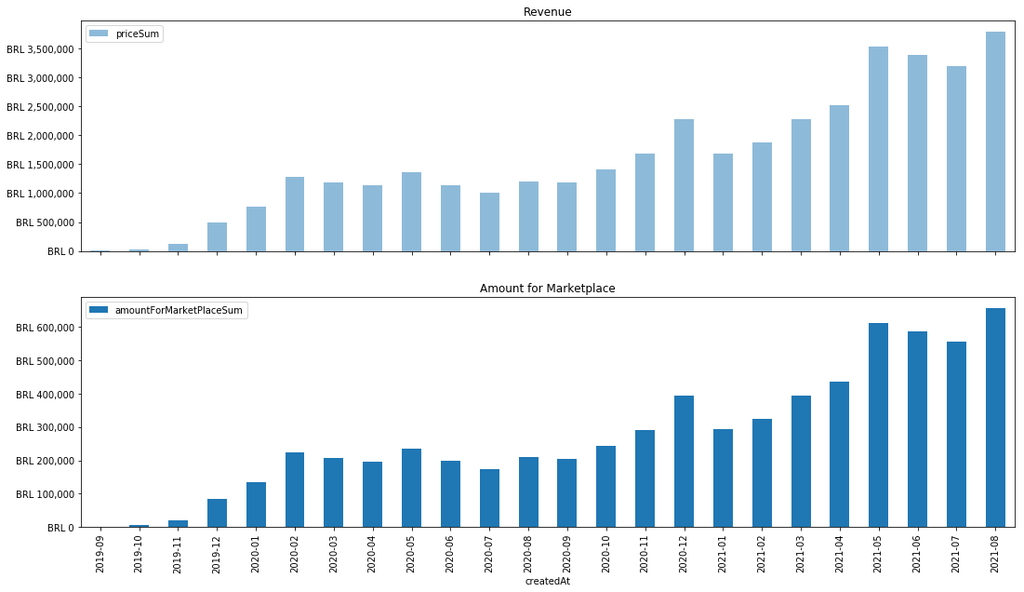

```python
fig, axarr = plt.subplots(2, sharex=True)

ax = fig.gca()

p1 = simulation_join_df[['priceSum']].plot(
    kind='bar',
    title='Revenue',
    figsize=(18,10),
    ax=axarr[0],
    legend=True,
    alpha=0.5
)

fmt = 'BRL {x:,.0f}'
tick = mtick.StrMethodFormatter(fmt)

p2 = simulation_join_df[['amountForMarketPlaceSum']].plot(
    kind='bar',
    title='Amount for Marketplace',
    figsize=(18,10),
    ax=axarr[1],
    legend=True
)

axarr[0].yaxis.set_major_formatter(tick)
axarr[1].yaxis.set_major_formatter(tick)

plt.show()
```

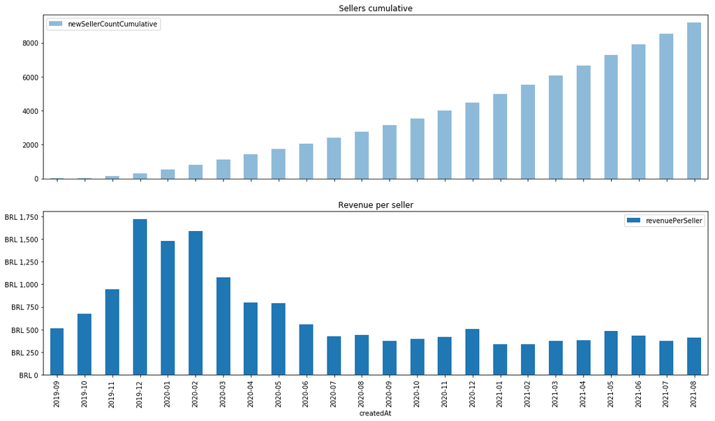

```python
fig, axarr = plt.subplots(2, sharex=True)

ax = fig.gca()

p1 = simulation_join_df[['newSellerCountCumulative']].plot(
    kind='bar',
    title='Sellers cumulative',
    figsize=(18,10),
    ax=axarr[0],
    legend=True,
    alpha=0.5
)

fmt = 'BRL {x:,.0f}'
tick = mtick.StrMethodFormatter(fmt)

p2 = simulation_join_df[['revenuePerSeller']].plot(
    kind='bar',
    title='Revenue per seller',
    figsize=(18,10),
    ax=axarr[1],
    legend=True
)

axarr[1].yaxis.set_major_formatter(tick)

plt.show()
```